# Project_2_Boston_data

```python
import pandas as pd
import numpy as np
import seaborn as sns
import matplotlib.pyplot as plt
import statsmodels.api as sm
```

### Download data

```python
boston = pd.read_csv('https://raw.githubusercontent.com/selva86/datasets/master/BostonHousing.csv')
```

```python
boston
```

|  | crim | zn | indus | chas | nox | rm | age | dis | rad | tax | ptratio | b | lstat | medv |
| --- | --- | --- | --- | --- | --- | --- | --- | --- | --- | --- | --- | --- | --- | --- |
| 0 | 0.00632 | 18.0 | 2.31 | 0 | 0.538 | 6.575 | 65.2 | 4.0900 | 1 | 296 | 15.3 | 396.90 | 4.98 | 24.0 |
| 1 | 0.02731 | 0.0 | 7.07 | 0 | 0.469 | 6.421 | 78.9 | 4.9671 | 2 | 242 | 17.8 | 396.90 | 9.14 | 21.6 |
| 2 | 0.02729 | 0.0 | 7.07 | 0 | 0.469 | 7.185 | 61.1 | 4.9671 | 2 | 242 | 17.8 | 392.83 | 4.03 | 34.7 |
| 3 | 0.03237 | 0.0 | 2.18 | 0 | 0.458 | 6.998 | 45.8 | 6.0622 | 3 | 222 | 18.7 | 394.63 | 2.94 | 33.4 |
| 4 | 0.06905 | 0.0 | 2.18 | 0 | 0.458 | 7.147 | 54.2 | 6.0622 | 3 | 222 | 18.7 | 396.90 | 5.33 | 36.2 |
| ... | ... | ... | ... | ... | ... | ... | ... | ... | ... | ... | ... | ... | ... | ... |
| 501 | 0.06263 | 0.0 | 11.93 | 0 | 0.573 | 6.593 | 69.1 | 2.4786 | 1 | 273 | 21.0 | 391.99 | 9.67 | 22.4 |
| 502 | 0.04527 | 0.0 | 11.93 | 0 | 0.573 | 6.120 | 76.7 | 2.2875 | 1 | 273 | 21.0 | 396.90 | 9.08 | 20.6 |
| 503 | 0.06076 | 0.0 | 11.93 | 0 | 0.573 | 6.976 | 91.0 | 2.1675 | 1 | 273 | 21.0 | 396.90 | 5.64 | 23.9 |
| 504 | 0.10959 | 0.0 | 11.93 | 0 | 0.573 | 6.794 | 89.3 | 2.3889 | 1 | 273 | 21.0 | 393.45 | 6.48 | 22.0 |
| 505 | 0.04741 | 0.0 | 11.93 | 0 | 0.573 | 6.030 | 80.8 | 2.5050 | 1 | 273 | 21.0 | 396.90 | 7.88 | 11.9 |

506 rows × 14 columns

**Data description**: The Boston data frame has 506 rows and 14 columns.

This data frame contains the following columns:

**crim** - per capita crime rate by town.  
**zn** - proportion of residential land zoned for lots over 25,000 sq.ft.  
**indus** - proportion of non-retail business acres per town.  
**chas** - Charles River dummy variable (= 1 if tract bounds river; 0 otherwise).  
**nox** - nitrogen oxides concentration (parts per 10 million).  
**rm** - average number of rooms per dwelling.  
**age** - proportion of owner-occupied units built prior to 1940.  
**dis** - weighted mean of distances to five Boston employment centres.  
**rad** - index of accessibility to radial highways.  
**tax** - full-value property-tax rate per $10,000$.  
**ptratio** - pupil-teacher ratio by town.  
**black** - $1000(Bk - 0.63)^2$ where Bk is the proportion of blacks by town.  
**lstat** - lower status of the population (percent).  
**medv** - median value of owner-occupied homes in $1000s$.

### Dividing dataset on features and target

```python
cols_to_drop = ['medv']
features = boston.drop(cols_to_drop, axis=1)
target = boston['medv']
```

```python
target
```

```
0      24.0
1      21.6
2      34.7
3      33.4
4      36.2
       ...
501    22.4
502    20.6
503    23.9
504    22.0
505    11.9
Name: medv, Length: 506, dtype: float64
```

### Look at the target distribution

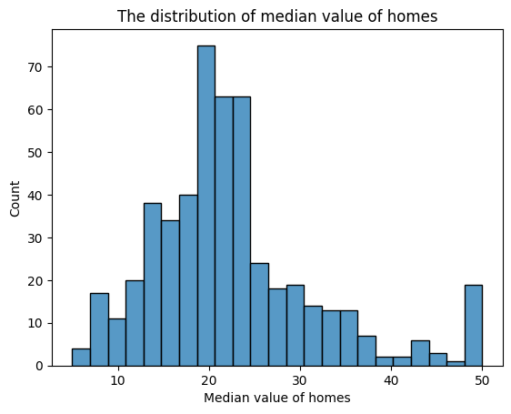

```python
ax = sns.histplot(target)
ax.set(xlabel='Median value of homes',
       ylabel='Count',
       title='The distribution of median value of homes')
plt.show()
```

### EDA

```python
features.info()
```

```
<class 'pandas.core.frame.DataFrame'>
RangeIndex: 506 entries, 0 to 505
Data columns (total 13 columns):
 #   Column   Non-Null Count  Dtype
---  ------   --------------  -----
 0   crim     506 non-null    float64
 1   zn       506 non-null    float64
 2   indus    506 non-null    float64
 3   chas     506 non-null    int64
 4   nox      506 non-null    float64
 5   rm       506 non-null    float64
 6   age      506 non-null    float64
 7   dis      506 non-null    float64
 8   rad      506 non-null    int64
 9   tax      506 non-null    int64
 10  ptratio  506 non-null    float64
 11  b        506 non-null    float64
 12  lstat    506 non-null    float64
dtypes: float64(10), int64(3)
memory usage: 51.5 KB
```

```python
features.isna().sum()
```

```
crim       0
zn         0
indus      0
chas       0
nox        0
rm         0
age        0
dis        0
rad        0
tax        0
ptratio    0
b          0
lstat      0
dtype: int64
```

## 1. Building a complete linear model

### Standardization

```python
means = features.mean(axis=0)
stds = features.std(axis=0)

scaled_features = (features - means) / stds

scaled_features.head()
```

|  | crim | zn | indus | chas | nox | rm | age | dis | rad | tax | ptratio | b | lstat |
| --- | --- | --- | --- | --- | --- | --- | --- | --- | --- | --- | --- | --- | --- |
| 0 | -0.419367 | 0.284548 | -1.286636 | -0.272329 | -0.144075 | 0.413263 | -0.119895 | 0.140075 | -0.981871 | -0.665949 | -1.457558 | 0.440616 | -1.074499 |
| 1 | -0.416927 | -0.487240 | -0.592794 | -0.272329 | -0.739530 | 0.194082 | 0.366803 | 0.556609 | -0.867024 | -0.986353 | -0.302794 | 0.440616 | -0.491953 |
| 2 | -0.416929 | -0.487240 | -0.592794 | -0.272329 | -0.739530 | 1.281446 | -0.265549 | 0.556609 | -0.867024 | -0.986353 | -0.302794 | 0.396035 | -1.207532 |
| 3 | -0.416338 | -0.487240 | -1.305586 | -0.272329 | -0.834458 | 1.015298 | -0.809088 | 1.076671 | -0.752178 | -1.105022 | 0.112920 | 0.415751 | -1.360171 |
| 4 | -0.412074 | -0.487240 | -1.305586 | -0.272329 | -0.834458 | 1.227362 | -0.510674 | 1.076671 | -0.752178 | -1.105022 | 0.112920 | 0.440616 | -1.025487 |

### Linear model

```python
X = sm.add_constant(scaled_features)
model_scaled = sm.OLS(target, X)
results_scaled = model_scaled.fit()

print(results_scaled.summary())
```

```
                            OLS Regression Results
==============================================================================
Dep. Variable:                   medv   R-squared:                       0.741
Model:                            OLS   Adj. R-squared:                  0.734
Method:                 Least Squares   F-statistic:                     108.1
Date:                Wed, 14 Dec 2022   Prob (F-statistic):          6.72e-135
Time:                        20:54:35   Log-Likelihood:                -1498.8
No. Observations:                 506   AIC:                             3026.
Df Residuals:                     492   BIC:                             3085.
Df Model:                          13
Covariance Type:            nonrobust
==============================================================================
                 coef    std err          t      P>|t|      [0.025      0.975]
------------------------------------------------------------------------------
const         22.5328      0.211    106.814      0.000      22.118      22.947
crim          -0.9291      0.283     -3.287      0.001      -1.484      -0.374
zn             1.0826      0.320      3.382      0.001       0.454       1.712
indus          0.1410      0.422      0.334      0.738      -0.688       0.970
chas           0.6824      0.219      3.118      0.002       0.252       1.112
nox           -2.0588      0.443     -4.651      0.000      -2.928      -1.189
rm             2.6769      0.294      9.116      0.000       2.100       3.254
age            0.0195      0.372      0.052      0.958      -0.711       0.750
dis           -3.1071      0.420     -7.398      0.000      -3.932      -2.282
rad            2.6649      0.578      4.613      0.000       1.530       3.800
tax           -2.0788      0.634     -3.280      0.001      -3.324      -0.834
ptratio       -2.0626      0.283     -7.283      0.000      -2.619      -1.506
b              0.8501      0.245      3.467      0.001       0.368       1.332
lstat         -3.7473      0.362    -10.347      0.000      -4.459      -3.036
==============================================================================
Omnibus:                      178.041   Durbin-Watson:                   1.078
Prob(Omnibus):                  0.000   Jarque-Bera (JB):              783.126
Skew:                           1.521   Prob(JB):                    8.84e-171
Kurtosis:                       8.281   Cond. No.                         9.82
==============================================================================

Notes:
[1] Standard Errors assume that the covariance matrix of the errors is correctly specified.
```

R-squared = 0.741  
Adj. R-squared = 0.734

## 2. Diagnostics of this model

### Correlation linearity check

```python
prediction_result_scaled = results_scaled.get_prediction(X)
target_pred_scaled = prediction_result.predicted_mean
```

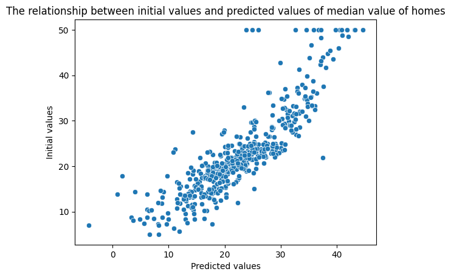

```python
ax = sns.scatterplot(x = target_pred_scaled, y = target)
ax.set(xlabel='Predicted values',
       ylabel='Initial values',
       title='The relationship between initial values and predicted values of median value of homes')
plt.show()
```

Initial values and predicted values after standardization are **linearly correlated** with each other.

### Checking influential observations

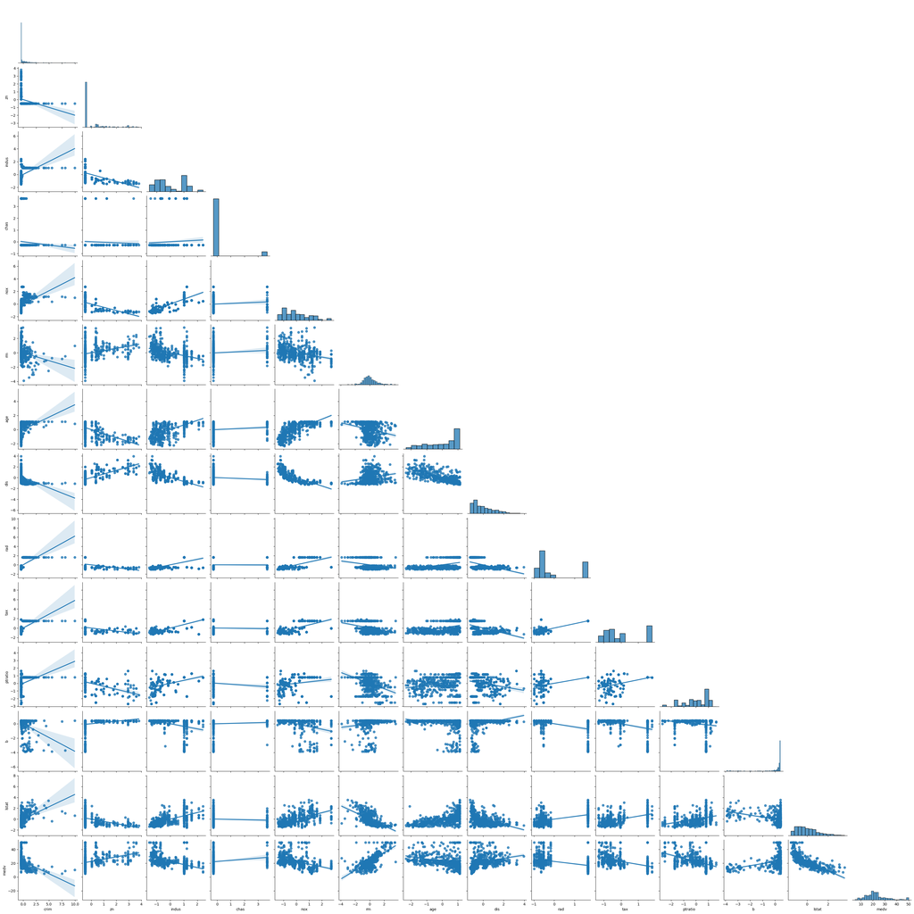

```python
sns.pairplot(pd.concat([scaled_features, target], axis=1), kind="reg", corner=True);
```

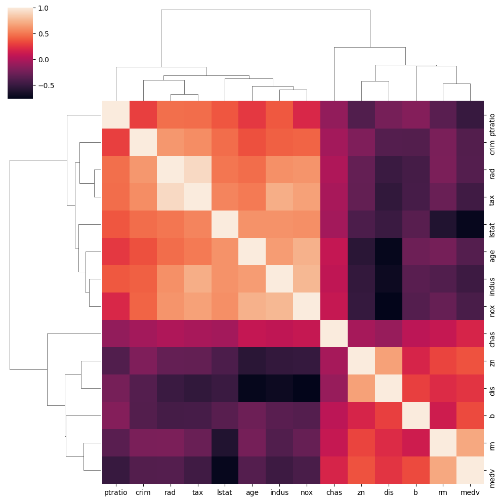

```python
sns.clustermap(pd.concat([scaled_features, target], axis=1).corr());
```

```python
pd.concat([scaled_features, target], axis=1).corr()
```

|  | crim | zn | indus | chas | nox | rm | age | dis | rad | tax | ptratio | b | lstat | medv |
| --- | --- | --- | --- | --- | --- | --- | --- | --- | --- | --- | --- | --- | --- | --- |
| crim | 1.000000 | -0.200469 | 0.406583 | -0.055892 | 0.420972 | -0.219247 | 0.352734 | -0.379670 | 0.625505 | 0.582764 | 0.289946 | -0.385064 | 0.455621 | -0.388305 |
| zn | -0.200469 | 1.000000 | -0.533828 | -0.042697 | -0.516604 | 0.311991 | -0.569537 | 0.664408 | -0.311948 | -0.314563 | -0.391679 | 0.175520 | -0.412995 | 0.360445 |
| indus | 0.406583 | -0.533828 | 1.000000 | 0.062938 | 0.763651 | -0.391676 | 0.644779 | -0.708027 | 0.595129 | 0.720760 | 0.383248 | -0.356977 | 0.603800 | -0.483725 |
| chas | -0.055892 | -0.042697 | 0.062938 | 1.000000 | 0.091203 | 0.091251 | 0.086518 | -0.099176 | -0.007368 | -0.035587 | -0.121515 | 0.048788 | -0.053929 | 0.175260 |
| nox | 0.420972 | -0.516604 | 0.763651 | 0.091203 | 1.000000 | -0.302188 | 0.731470 | -0.769230 | 0.611441 | 0.668023 | 0.188933 | -0.380051 | 0.590879 | -0.427321 |
| rm | -0.219247 | 0.311991 | -0.391676 | 0.091251 | -0.302188 | 1.000000 | -0.240265 | 0.205246 | -0.209847 | -0.292048 | -0.355501 | 0.128069 | -0.613808 | 0.695360 |
| age | 0.352734 | -0.569537 | 0.644779 | 0.086518 | 0.731470 | -0.240265 | 1.000000 | -0.747881 | 0.456022 | 0.506456 | 0.261515 | -0.273534 | 0.602339 | -0.376955 |
| dis | -0.379670 | 0.664408 | -0.708027 | -0.099176 | -0.769230 | 0.205246 | -0.747881 | 1.000000 | -0.494588 | -0.534432 | -0.232471 | 0.291512 | -0.496996 | 0.249929 |
| rad | 0.625505 | -0.311948 | 0.595129 | -0.007368 | 0.611441 | -0.209847 | 0.456022 | -0.494588 | 1.000000 | 0.910228 | 0.464741 | -0.444413 | 0.488676 | -0.381626 |
| tax | 0.582764 | -0.314563 | 0.720760 | -0.035587 | 0.668023 | -0.292048 | 0.506456 | -0.534432 | 0.910228 | 1.000000 | 0.460853 | -0.441808 | 0.543993 | -0.468536 |
| ptratio | 0.289946 | -0.391679 | 0.383248 | -0.121515 | 0.188933 | -0.355501 | 0.261515 | -0.232471 | 0.464741 | 0.460853 | 1.000000 | -0.177383 | 0.374044 | -0.507787 |
| b | -0.385064 | 0.175520 | -0.356977 | 0.048788 | -0.380051 | 0.128069 | -0.273534 | 0.291512 | -0.444413 | -0.441808 | -0.177383 | 1.000000 | -0.366087 | 0.333461 |
| lstat | 0.455621 | -0.412995 | 0.603800 | -0.053929 | 0.590879 | -0.613808 | 0.602339 | -0.496996 | 0.488676 | 0.543993 | 0.374044 | -0.366087 | 1.000000 | -0.737663 |
| medv | -0.388305 | 0.360445 | -0.483725 | 0.175260 | -0.427321 | 0.695360 | -0.376955 | 0.249929 | -0.381626 | -0.468536 | -0.507787 | 0.333461 | -0.737663 | 1.000000 |

#### According to these graphs and the table, it can be seen that the following observations are most correlated with the target - median value of homes (and, accordingly, are influential):

**lstat** (-0.737663) - lower status of the population  
**rm** (0.695360) - average number of rooms per dwelling  
**ptratio** (-0.507787) - pupil-teacher ratio by town  
**indus** (-0.483725) - proportion of non-retail business acres per town  
**tax** (-0.468536) - full-value property-tax rate  
**nox** (-0.427321) - nitrogen oxides concentration (parts per 10 million)  
**crim** (-0.388305) - per capita crime rate by town.

### Independence of observations

#### VIF

```python
from statsmodels.stats.outliers_influence import variance_inflation_factor
```

```python
vif_data = pd.DataFrame()
vif_data["feature"] = X.columns
vif_data["VIF"] = [variance_inflation_factor(X.values, i)
                          for i in range(len(X.columns))]

vif_data
```

|  | feature | VIF |
| --- | --- | --- |
| 0 | const | 1.000000 |
| 1 | crim | 1.792192 |
| 2 | zn | 2.298758 |
| 3 | indus | 3.991596 |
| 4 | chas | 1.073995 |
| 5 | nox | 4.393720 |
| 6 | rm | 1.933744 |
| 7 | age | 3.100826 |
| 8 | dis | 3.955945 |
| 9 | rad | 7.484496 |
| 10 | tax | 9.008554 |
| 11 | ptratio | 1.799084 |
| 12 | b | 1.348521 |
| 13 | lstat | 2.941491 |

Features **tax** and **rad** are well explained by other features (that is, they are **dependent on other observations**).  
We can try to remove these features one by one, build a model and evaluate the results.

```python
model_without_tax = sm.OLS(target, X.drop(columns=["tax"]))
results_without_tax = model_without_tax.fit()

print(results_without_tax.summary())
```

```
                            OLS Regression Results
==============================================================================
Dep. Variable:                   medv   R-squared:                       0.735
Model:                            OLS   Adj. R-squared:                  0.729
Method:                 Least Squares   F-statistic:                     113.9
Date:                Wed, 14 Dec 2022   Prob (F-statistic):          1.21e-133
Time:                        21:40:32   Log-Likelihood:                -1504.3
No. Observations:                 506   AIC:                             3035.
Df Residuals:                     493   BIC:                             3089.
Df Model:                          12
Covariance Type:            nonrobust
==============================================================================
                 coef    std err          t      P>|t|      [0.025      0.975]
------------------------------------------------------------------------------
const         22.5328      0.213    105.772      0.000      22.114      22.951
crim          -0.9181      0.285     -3.216      0.001      -1.479      -0.357
zn             0.8483      0.315      2.692      0.007       0.229       1.467
indus         -0.4650      0.383     -1.214      0.225      -1.218       0.288
chas           0.7694      0.219      3.507      0.000       0.338       1.200
nox           -2.1671      0.446     -4.862      0.000      -3.043      -1.291
rm             2.7484      0.296      9.294      0.000       2.167       3.329
age           -0.0170      0.375     -0.045      0.964      -0.754       0.720
dis           -3.1339      0.424     -7.390      0.000      -3.967      -2.301
rad            1.1718      0.359      3.262      0.001       0.466       1.878
ptratio       -2.1327      0.285     -7.478      0.000      -2.693      -1.572
b              0.8715      0.248      3.521      0.000       0.385       1.358
lstat         -3.7291      0.366    -10.198      0.000      -4.448      -3.011
==============================================================================
Omnibus:                      168.699   Durbin-Watson:                   1.089
Prob(Omnibus):                  0.000   Jarque-Bera (JB):              702.173
Skew:                           1.452   Prob(JB):                    3.35e-153
Kurtosis:                       7.987   Cond. No.                         5.87
==============================================================================

Notes:
[1] Standard Errors assume that the covariance matrix of the errors is correctly specified.
```

R-squared = 0.735  
Adj. R-squared = 0.729  
R-squared metrics decreased compared with previous model.

```python
def calculate_vif(X):
    vif_data = pd.DataFrame()
    vif_data["feature"] = X.columns
    vif_data["VIF"] = [variance_inflation_factor(X.values, i)
                            for i in range(len(X.columns))]

    return vif_data
```

```python
calculate_vif(X.drop(columns=["tax"]))
```

|  | feature | VIF |
| --- | --- | --- |
| 0 | const | 1.000000 |
| 1 | crim | 1.791940 |
| 2 | zn | 2.184240 |
| 3 | indus | 3.226015 |
| 4 | chas | 1.058220 |
| 5 | nox | 4.369271 |
| 6 | rm | 1.923075 |
| 7 | age | 3.098044 |
| 8 | dis | 3.954446 |
| 9 | rad | 2.837494 |
| 10 | ptratio | 1.788839 |
| 11 | b | 1.347564 |
| 12 | lstat | 2.940800 |

```python
model_without_rad = sm.OLS(target, X.drop(columns=["rad"]))
results_without_rad = model_without_rad.fit()

print(results_without_rad.summary())
```

```
                            OLS Regression Results
==============================================================================
Dep. Variable:                   medv   R-squared:                       0.729
Model:                            OLS   Adj. R-squared:                  0.723
Method:                 Least Squares   F-statistic:                     110.8
Date:                Wed, 14 Dec 2022   Prob (F-statistic):          1.92e-131
Time:                        21:42:00   Log-Likelihood:                -1509.5
No. Observations:                 506   AIC:                             3045.
Df Residuals:                     493   BIC:                             3100.
Df Model:                          12
Covariance Type:            nonrobust
==============================================================================
                 coef    std err          t      P>|t|      [0.025      0.975]
------------------------------------------------------------------------------
const         22.5328      0.215    104.682      0.000      22.110      22.956
crim          -0.5810      0.278     -2.090      0.037      -1.127      -0.035
zn             0.9264      0.325      2.852      0.005       0.288       1.565
indus         -0.4007      0.413     -0.969      0.333      -1.213       0.412
chas           0.7910      0.222      3.563      0.000       0.355       1.227
nox           -1.7685      0.447     -3.956      0.000      -2.647      -0.890
rm             2.8910      0.296      9.772      0.000       2.310       3.472
age           -0.1105      0.378     -0.292      0.770      -0.854       0.633
dis           -3.1378      0.428     -7.323      0.000      -3.980      -2.296
tax            0.2249      0.398      0.565      0.573      -0.557       1.007
ptratio       -1.8158      0.284     -6.398      0.000      -2.373      -1.258
b              0.7683      0.250      3.079      0.002       0.278       1.259
lstat         -3.6878      0.369     -9.986      0.000      -4.413      -2.962
==============================================================================
Omnibus:                      189.296   Durbin-Watson:                   1.059
Prob(Omnibus):                  0.000   Jarque-Bera (JB):              907.772
Skew:                           1.596   Prob(JB):                    7.58e-198
Kurtosis:                       8.733   Cond. No.                         5.84
==============================================================================

Notes:
[1] Standard Errors assume that the covariance matrix of the errors is correctly specified.
```

R-squared = 0.729  
Adj. R-squared = 0.723  
R-squared metrics decreased more compared with previous model.

```python
calculate_vif(X.drop(columns=["rad"]))
```

|  | feature | VIF |
| --- | --- | --- |
| 0 | const | 1.000000 |
| 1 | crim | 1.664471 |
| 2 | zn | 2.273018 |
| 3 | indus | 3.682265 |
| 4 | chas | 1.061561 |
| 5 | nox | 4.304929 |
| 6 | rm | 1.885425 |
| 7 | age | 3.083009 |
| 8 | dis | 3.954951 |
| 9 | tax | 3.415289 |
| 10 | ptratio | 1.734873 |
| 11 | b | 1.341459 |
| 12 | lstat | 2.937752 |

```python
model_without_rad_tax = sm.OLS(target, X.drop(columns=["rad", "tax"]))
results_without_rad_tax = model_without_rad_tax.fit()

print(results_without_rad_tax.summary())
```

```
                            OLS Regression Results
==============================================================================
Dep. Variable:                   medv   R-squared:                       0.729
Model:                            OLS   Adj. R-squared:                  0.723
Method:                 Least Squares   F-statistic:                     121.0
Date:                Wed, 14 Dec 2022   Prob (F-statistic):          2.00e-132
Time:                        21:49:42   Log-Likelihood:                -1509.7
No. Observations:                 506   AIC:                             3043.
Df Residuals:                     494   BIC:                             3094.
Df Model:                          11
Covariance Type:            nonrobust
==============================================================================
                 coef    std err          t      P>|t|      [0.025      0.975]
------------------------------------------------------------------------------
const         22.5328      0.215    104.755      0.000      22.110      22.955
crim          -0.5284      0.262     -2.019      0.044      -1.043      -0.014
zn             0.9683      0.316      3.064      0.002       0.347       1.589
indus         -0.3144      0.384     -0.819      0.413      -1.069       0.440
chas           0.7836      0.221      3.538      0.000       0.348       1.219
nox           -1.6912      0.425     -3.977      0.000      -2.527      -0.856
rm             2.9048      0.295      9.859      0.000       2.326       3.484
age           -0.1209      0.378     -0.320      0.749      -0.863       0.621
dis           -3.1351      0.428     -7.322      0.000      -3.976      -2.294
ptratio       -1.7564      0.263     -6.669      0.000      -2.274      -1.239
b              0.7491      0.247      3.032      0.003       0.264       1.234
lstat         -3.6834      0.369     -9.983      0.000      -4.408      -2.959
==============================================================================
Omnibus:                      193.860   Durbin-Watson:                   1.053
Prob(Omnibus):                  0.000   Jarque-Bera (JB):              958.429
Skew:                           1.628   Prob(JB):                    7.58e-209
Kurtosis:                       8.904   Cond. No.                         5.23
==============================================================================

Notes:
[1] Standard Errors assume that the covariance matrix of the errors is correctly specified.
```

R-squared = 0.729  
Adj. R-squared = 0.723  
R-squared metrics are the same as when throwing only the feature **rad**

```python
calculate_vif(X.drop(columns=["rad", "tax"]))
```

|  | feature | VIF |
| --- | --- | --- |
| 0 | const | 1.000000 |
| 1 | crim | 1.478206 |
| 2 | zn | 2.154483 |
| 3 | indus | 3.179166 |
| 4 | chas | 1.057805 |
| 5 | nox | 3.901348 |
| 6 | rm | 1.872532 |
| 7 | age | 3.075755 |
| 8 | dis | 3.954443 |
| 9 | ptratio | 1.496077 |
| 10 | b | 1.316559 |
| 11 | lstat | 2.936487 |

After removing the dependent variables from the model, in all cases, the correlation of other features with each other became less.

### Normality of distribution and constancy of variance

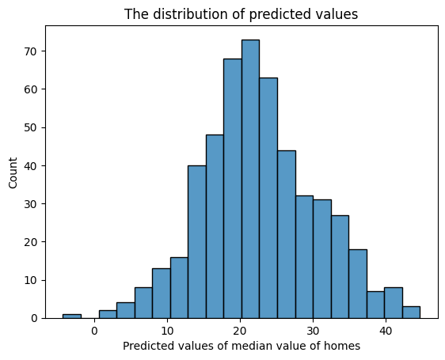

```python
ax = sns.histplot(target_pred_scaled)
ax.set(xlabel='Predicted values of median value of homes',
       ylabel='Count',
       title='The distribution of predicted values')
plt.show()
```

Predicted values are normally distributed

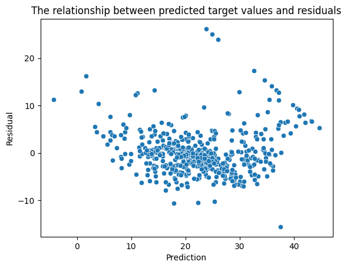

```python
resid_full = target - target_pred_scaled

ax = sns.scatterplot(x = target_pred_scaled, y = resid_full)
ax.set(xlabel='Prediction',
       ylabel='Residual',
      title = 'The relationship between predicted target values and residuals')
plt.show()
```

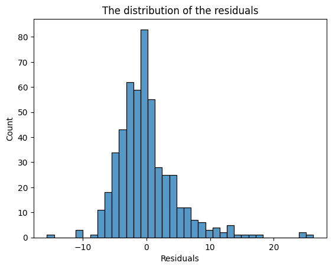

```python
ax = sns.histplot(resid_full)
ax.set(xlabel='Residuals',
       ylabel='Count',
       title='The distribution of the residuals')
plt.show()
```

### Graph of cost predictions from a variable that has the highest modulo coefficient (lstat)

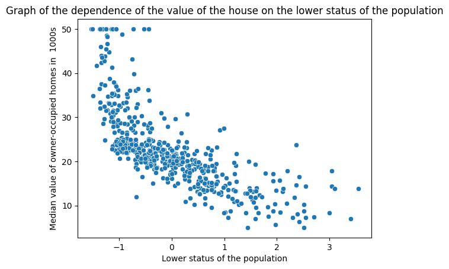

```python
ax = sns.scatterplot(x = X["lstat"], y = target)
ax.set(xlabel='Lower status of the population',
       ylabel='Median value of owner-occupied homes in  1000s',
       title='Graph of the dependence of the value of the house on the lower status of the population')
plt.show()
```

**The model shows good R-squared metrics and quite well predicts the median value of a house according to the given features.**

## Additional part

Above it was shown that the lower status of the population correlates well with the average cost of a house. Therefore, in order to maximize the price of a house for sale, it is necessary to **build a house in an area with a high population status**.

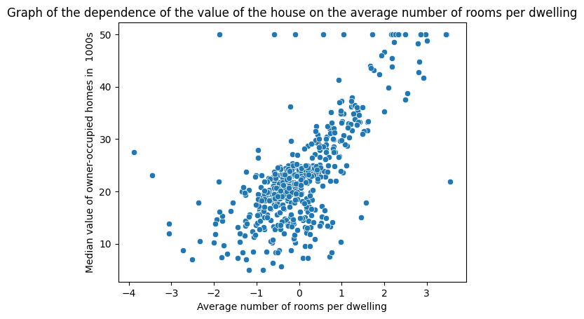

```python
ax = sns.scatterplot(x = X["rm"], y = target)
ax.set(xlabel='Average number of rooms per dwelling',
       ylabel='Median value of owner-occupied homes in  1000s',
       title='Graph of the dependence of the value of the house on the average number of rooms per dwelling')
plt.show()
```

So, the next feature that have a good correlation with target is **average number of rooms per dwelling**.  
But with an increase in the number of rooms, the cost of building one apartment increases, so I’m not sure if this is the point that you should focus on in the first place in order to maximize the price for the house.

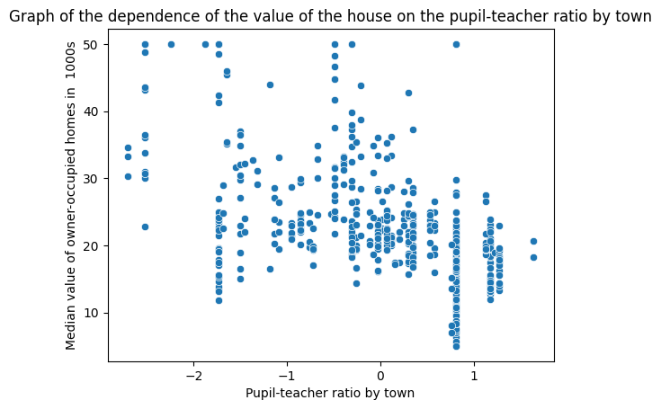

```python
ax = sns.scatterplot(x = X["ptratio"], y = target)
ax.set(xlabel='Pupil-teacher ratio by town',
       ylabel='Median value of owner-occupied homes in  1000s',
       title='Graph of the dependence of the value of the house on the pupil-teacher ratio by town')
plt.show()
```

The next feature - **pupil-teacher ratio by town**.  
A slight negative correlation is seen, but more data or more information is needed to make a definitive conclusion about the application of the significance of this feature in maximizing the price of a house.

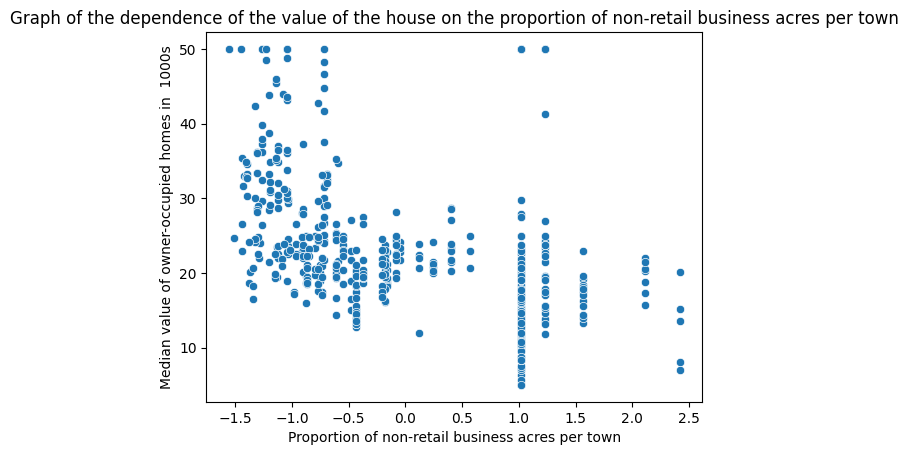

```python
ax = sns.scatterplot(x = X["indus"], y = target)
ax.set(xlabel='Proportion of non-retail business acres per town',
       ylabel='Median value of owner-occupied homes in  1000s',
       title='Graph of the dependence of the value of the house on the proportion of non-retail business acres per town')
plt.show()
```

Proportion of non-retail business acres per town also negatively correlates with the target. That is, in order to maximize the price of a house, **you should build a house either in the town with a low share of non-retail business, or minimize their number in the area that you are building**.

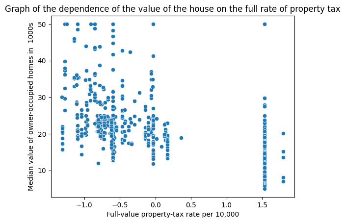

```python
ax = sns.scatterplot(x = X["tax"], y = target)
ax.set(xlabel='Full-value property-tax rate per 10,000',
       ylabel='Median value of owner-occupied homes in  1000s',
       title='Graph of the dependence of the value of the house on the full rate of property tax')
plt.show()
```

The nex feture - full-value property-tax rate per $10000$.  
There is also a negative correlation here. Moreover, the signs were divided into 2 groups: a low full rate of property tax in houses with a high cost and a high full rate of property tax in houses with a relatively low cost.  
Therefore, it can be assumed that in order to maximize the value of a house, it is necessary to **build it in an area or city with a low full-value property-tax rate**.

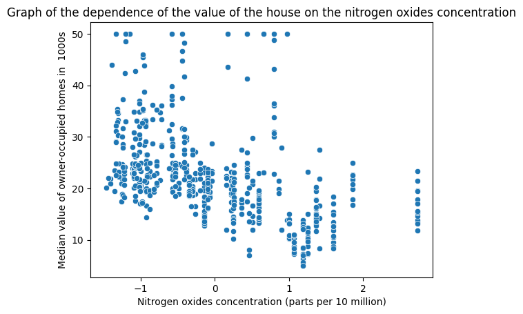

```python
ax = sns.scatterplot(x = X["nox"], y = target)
ax.set(xlabel='Nitrogen oxides concentration (parts per 10 million)',
       ylabel='Median value of owner-occupied homes in  1000s',
       title='Graph of the dependence of the value of the house on the nitrogen oxides concentration')
plt.show()
```

Nitrogen oxides concentration (parts per 10 million) slightly negatively correlated with the target variable.  
Accordingly, it can be concluded that the lower nitrogen oxides concentration, the higher value of a house in that area or city. Therefore, to maximize the value of a house, it is necessary to **build it in an area or city with the least nitrogen oxides concentration**.

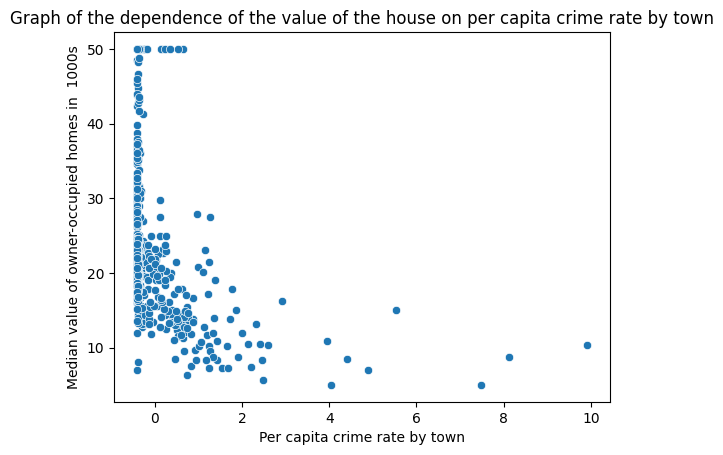

```python
ax = sns.scatterplot(x = X["crim"], y = target)
ax.set(xlabel='Per capita crime rate by town',
       ylabel='Median value of owner-occupied homes in  1000s',
       title='Graph of the dependence of the value of the house on per capita crime rate by town')
plt.show()
```

Per capita crime rate by town is negatively correlated with the median value of a house. It can be seen that those houses that are located in the area with the highest crime rate are cheaper than those in areas where crime is minimal.  
Accordingly, in order to maximize the value of a house, it is necessary to **build it in an area with a minimum level of crime**.

### Let's make conclusions:

To maximize the value of a house it is nesessary to build in an area with:

1. high population status
2. low share of non-retail business, or minimize their number in the area that you are building
3. low full-value property-tax rate
4. the least nitrogen oxides concentration
5. minimum level of crime